# 霍恩博尔加斯舍恩湖鹤群观测数据分析报告 (1994–2024)

lawiet

2025-10-04

该数据源自于`https://www.hornborga.com/naturen/transtatistik/`，

由Contributor `Carl Borstell`提供。

> 背景介绍

> 30多年来，停靠在瑞典西约特兰州霍恩博尔加斯约恩湖（“霍恩堡湖”）的鹤一直从 春季和秋季的霍恩博尔加舍恩野外站 ，因为它们在每年的迁徙过程中经过。

> [!tip] 提示  
> 接下来从三个角度出发分析霍恩堡湖的鹤迁徙过程的观测数据 1.在过去的 30 年里，霍恩博尔加斯舍恩湖的鹤数量变化情况 2.如果您想看到成千上万的鹤，一年中什么时候是最佳游览时间？ 3.是否可以从天气模式预测鹤的到来？

### 数据清洗

由于数据存在部分缺失（如：NA） 对现有数据的缺失项剔除，并修改数据类型（比如时间数据date），将其拆分成year,month,week_of_year等等variables方便后续分析

```r
cranes <- read.csv("C:/Users/LMH/Desktop/cranes_data.csv")
cleaned_cranes <- cranes %>%
  mutate(date = as.character(date)) %>%
  mutate(date = as.Date(date, format = "%Y/%m/%d")) %>%
  mutate(
    year = format(date, "%Y"),
    month = format(date, "%m"),
    week_of_year = lubridate::week(date)
  ) %>%

  filter(!is.na(observations)) %>%
  mutate(observations = as.numeric(observations))
glimpse(cleaned_cranes)
```

```
## Rows: 1,387
## Columns: 7
## $ date               <date> 2024-10-03, 2024-09-30, 2024-09-23, 2024-09-19, 20…
## $ observations       <dbl> 408, 14940, 18450, 14900, 12900, 8660, 9720, 7850, …
## $ comment            <chr> "Last count of season", NA, NA, NA, NA, NA, NA, NA,…
## $ weather_disruption <lgl> FALSE, FALSE, FALSE, FALSE, FALSE, FALSE, FALSE, FA…
## $ year               <chr> "2024", "2024", "2024", "2024", "2024", "2024", "20…
## $ month              <chr> "10", "09", "09", "09", "09", "09", "09", "09", "08…
## $ week_of_year       <dbl> 40, 40, 39, 38, 38, 37, 36, 36, 35, 34, 34, 16, 15,…
```

## Q1：在过去的 30 年里，霍恩博尔加斯舍恩湖的鹤数量变化情况

- 在清洗后的数据中，我们可以将每年都分成一组，然后统计每一组的最大观测数（observations）。按照年份作为横轴，年度最大观测数为纵轴，我们可以获得相关的折线图，并推算出线性回归（红色虚线表示），如下图（Annual Maximum Crane Observations Trend）：

```r
yearly_max_counts <- cleaned_cranes %>%
  group_by(year) %>%
  summarise(
    max_count = max(observations, na.rm = TRUE),
    .groups = 'drop'
  ) %>%
  mutate(year = as.numeric(year))
print(yearly_max_counts)
```

```
## # A tibble: 31 × 2
##     year max_count
##    <dbl>     <dbl>
##  1  1994      4992
##  2  1995      5280
##  3  1996      5880
##  4  1997      6860
##  5  1998      8625
##  6  1999      7800
##  7  2000      8920
##  8  2001      6750
##  9  2002      8760
## 10  2003     11050
## # ℹ 21 more rows
```

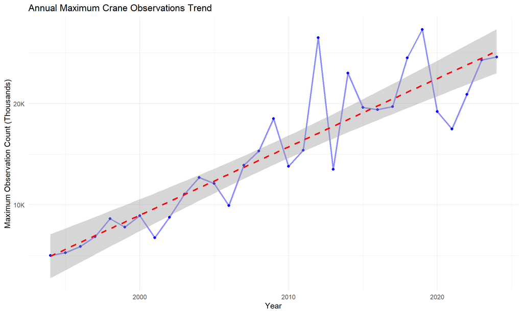

```r
yearly_max_plot <-yearly_max_counts %>%
  ggplot(aes(x = year, y = max_count)) +
  geom_line(color = "#8C8CFF", linewidth = 1) +
  geom_point(color = "#0000ff", size = 1.5) +
  geom_smooth(method = "lm", color = "red", se = TRUE, linetype = "dashed") +
  labs(
    title = "Annual Maximum Crane Observations Trend",
    x = "Year",
    y = "Maximum Observation Count (Thousands)") +
  scale_y_continuous(labels = scales::label_number(scale = 1/1000, suffix = "K")) +
  theme_minimal()
print(yearly_max_plot)
```

- 结论：霍恩博尔加斯舍恩湖作为鹤类栖息地的重要性在不断提升，鹤群的数量在过去 30 年里增长显著。

## Q2：如果您想看到成千上万的鹤，一年中什么时候是最佳游览时间？

- 回答该问题，最重要的是统计全部年份中每一周鹤的平均观测数(Average Observation Count)。于是我们可以将week_of_year相同的分一组，并计算每一组的平均观测数。如下图所示（Seasonal Pattern of Crane Observations），其中红色点线表明观测数达到5千。

```r
weekly_avg_counts <- cleaned_cranes %>%
  group_by(week_of_year) %>%
  summarise(
    avg_count = mean(observations),
    .groups = 'drop'
  )
print(weekly_avg_counts)
```

```
## # A tibble: 21 × 2
##    week_of_year avg_count
##           <dbl>     <dbl>
##  1           10      200.
##  2           11      814.
##  3           12     3872.
##  4           13     8486.
##  5           14    10725.
##  6           15     7970.
##  7           16     3138.
##  8           17     1232.
##  9           18     1500
## 10           32      540
## # ℹ 11 more rows
```

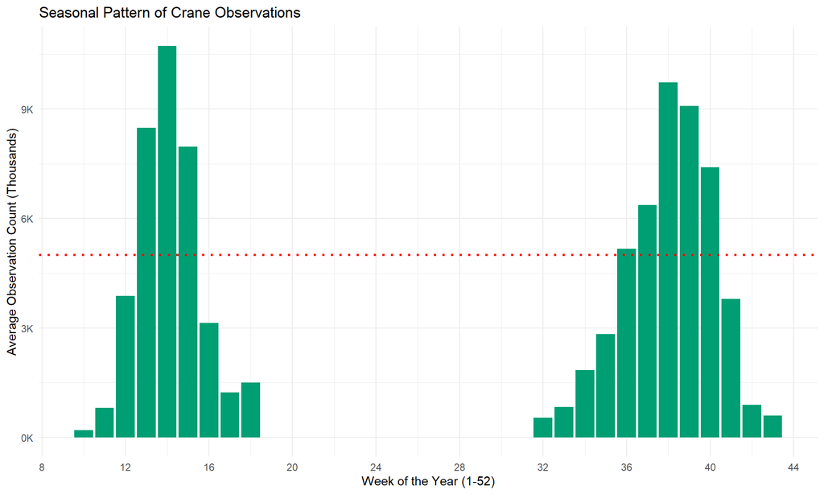

```r
weekly_avg_plot <- weekly_avg_counts %>%
  ggplot(aes(x = week_of_year, y = avg_count)) +
  geom_col(fill = "#009E73") +
  geom_hline(yintercept = 5000, linetype = "dotted", color = "red", linewidth = 1) +
  labs(
    title = "Seasonal Pattern of Crane Observations",
    x = "Week of the Year (1-52)",
    y = "Average Observation Count (Thousands)") +
  scale_y_continuous(labels = scales::label_number(scale = 1/1000, suffix = "K")) +
  scale_x_continuous(breaks = seq(0, 52, by = 4)) +
  theme_minimal()
print(weekly_avg_plot)
```

## Q3：是否可以从天气模式预测鹤的到来？

- 在天气未导致观测中断（False）和天气导致观测中断（True）这两种情况下，观测到的鹤数量（observations）的差异，主要从平均观测数，中位数观测数，标准差

```r
cleaned_cranes <- cleaned_cranes %>%
  mutate(weather_disruption = factor(weather_disruption,
                                     levels = c(FALSE, TRUE),
                                     labels = c("No Disruption", "Weather Disruption")))

summary_stats_r <- cleaned_cranes %>%
  group_by(weather_disruption) %>%
  summarise(
    N = n(),
    Mean_Observations = mean(observations, na.rm = TRUE),
    Median_Observations = median(observations, na.rm = TRUE),
    SD_Observations = sd(observations, na.rm = TRUE)
  ) %>%
  ungroup()

print("观测数与天气中断情况的统计比较 (来自 cleaned_cranes):")
```

```
## [1] "观测数与天气中断情况的统计比较 (来自 cleaned_cranes):"
```

```r
print(summary_stats_r)
```

```
## # A tibble: 2 × 5
##   weather_disruption     N Mean_Observations Median_Observations SD_Observations
##   <fct>              <int>             <dbl>               <dbl>           <dbl>
## 1 No Disruption       1384             6066.                4500           5533.
## 2 Weather Disruption     3             5000                    0           8660.
```

- 结论：观测活动未中断的日子，观测到的鹤数量更高。 但是该结论非常有限，在天气中断（weather_disruption = TRUE）的情况下，最终仍有有效观测数量（observations）的记录只有 N=3 条，亟需更多样本。